# Statistisk inferensteori Modellval (H & B, Kapitel 7)

## Modellval, Weibull mot Exponential

- \(Exponential(\beta)=Weibull(1,\beta)\), vi kan testa \(\alpha=1\) i Weibullmodell.

```r
T.L <- -2 * (l.weib(1, beta.hat.0, ac) - l.weib(alpha.hat, beta.hat, ac))
p <- 1 - pchisq(T.L, 1)
p
```

```
## [1] 0.08047122
```

## Occams rakkniv (William av Occam, 1285-1347)

[figure not shown]

*Non est ponenda pluralitas sine necessitate* [krångla inte till saker i onödan].

Välj exponentialmodellen!

## Modellval

- hur jämför vi två modeller som inte är nästlade?
- hur jämför vi fler än två modeller med hypotestest?

## Kullback-Leibler avstånd

**Definition:** (H & B, A.3.8) Kullback-Leibler avvikelsen av tätheten \(p\) från \(q\) är \[ D(q|p)= E_q(\log(q(X)))-E_q(\log(p(X))), \] där \(X\sim q\).

## Kullback-Leibler avstånd

Givet \(m\) modeller \(M_1,\ldots, M_m\) med tätheter \(p_1(x), \ldots, p_m(x)\) vill vi välja modellen som minimerar \[ D(q|p_i)=C-E_q\log(p_i(X)) \] där \(q\) är den sanna tätheten, alternativt maximerar \(E_q\log(p_i(X))\).

*Problem:* Tätheterna \(p_i\) beror på okända parametrar.

## Vad händer med ML-skattaren om modellen är fel?

Låt \(q\) vara den sanna tätheten, ML-skattaren maximerar

\[ \frac{1}{n}\sum_{i=1}^n\log p(X_i|\theta)\approx E_q(\log p(X_i|\theta))=C-D(q|p(\cdot|\theta)) \] d.v.s. den väljer (asymptotiskt) \(\theta\) så att Kullback-Leibler avståndet till sanna tätheten minimeras.

Därför rimligt att använda \(\hat{\theta}\) även när modellen är "fel".

## Exempel: Gamma anpassad till Normal

```r
x <- rnorm(100, mean = 4, sd = 1)
nl.gamma <- function(theta, data){
    -sum(log(dgamma(data, theta[1], theta[2])))
}
theta.hat <- optim(c(5,1), nl.gamma, data = x)$par
theta.hat
```

```
## [1] 19.450146  4.733772
```

## Exempel: Gamma anpassad till Normal

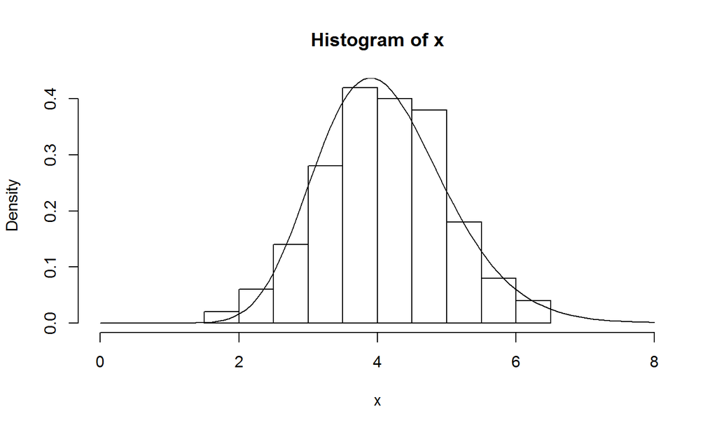

## Exempel: Exponential anpassad till Normal

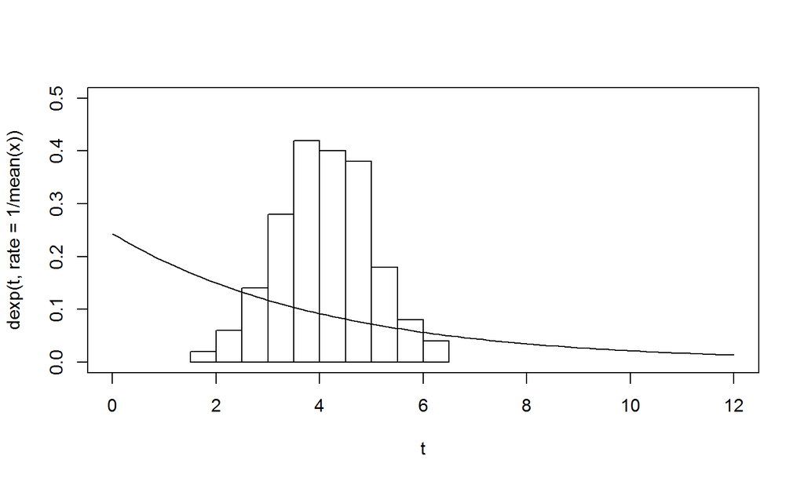

## Hirotugu Akaike (1927-2009)

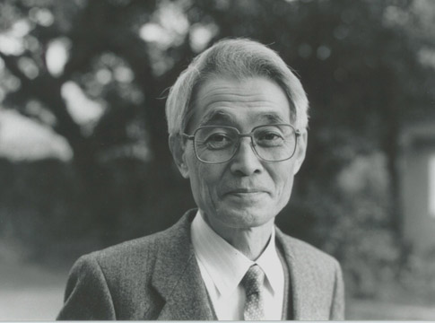

Akaike föreslog att maximera \[ K(i)=E_q\log p_i(X|\hat{\theta}_i(Y)) \] där \(X\) och \(Y\) är oberoende med täthet \(q\).

## AIC

En naturlig skattning är \[ \hat{K}(i)=\frac{1}{n}\sum_{j=1}^n \log p_j(x_j|\hat{\theta}_i(x)) \] som dock överskattar \(K(i)\) då vi använder \(x\) istället för \(y\). Akaike visade att

\[ E_q(\hat{K}(i))-K(i)\approx \frac{p_i}{n}, \] där \(p_i\) är antalet parametrar i modell \(i\) och föreslog *Akaikes informationskriterium* \[ AIC(i)=-2n(\hat{K}(i)-\frac{p_i}{n})=-2l_i(\hat{\theta}_i)+2p_i \]

## AIC, Exponential vs Weibull

```r
AIC.Weib <- -2 * l.weib(alpha.hat, beta.hat, ac) + 2 * 2
AIC.Weib
```

```
## [1] 301.6843
```

```r
AIC.Exp <- -2 * l.weib(1, beta.hat.0, ac) + 2 * 1
AIC.Exp
```

```
## [1] 302.7397
```

AIC förordar Weibullmodellen.

## Dela upp i träningsdata/testdata

- Bias i \(\hat{K}\) kommer sig av att vi använder samma data två ggr.
- Ett alternativ vore att dela upp data i två delar \((x,y)\) och skatta \(K\) med \[ \frac{1}{n_x}\sum_{i=1}^{n_x} \log p(x_i|\hat{\theta}_i(y)), \] där \(\hat{\theta}_i(y)\) är ML-skattaren baserat på \(y\) i modell \(i\).

## Leave-one-out korsvalidering

Vanligast är \[ K_{CV}(i)=\frac{1}{n}\sum_{j=1}^n\log p(x_j|\hat{\theta}_i(x_{-j})) \] där \(x_{-j}\) är \(x\) utan observation \(j\).

## Korsvalidering, Exponential vs Weibull

```r
nl.weib <- function(theta, data){-L.weib(theta[1], theta[2], data)}
K.w <- numeric(length(ac)); K.e <- numeric(length(ac))
for (j in 1:length(ac)){
    x.j <- ac[-j]
    theta.hat <- optim(c(1, 0.01), nl.weib, data = x.j)$par
    K.w[j] <- log(dweibull(ac[j], theta.hat[1], scale = 1 / theta.hat[2]))
    K.e[j] <- log(dexp(ac[j], rate = theta.hat[2]))
}
-2 * sum(K.w) #Weibull
```

```
## [1] 300.3195
```

```r
-2 * sum(K.e) #Exponential
```

```
## [1] 302.1695
```

## Bayesianskt modellval

## Modellsannolikheter

Ansätt apriorisannolikheter \(P(M_i)\), aposteriori blir

\[ P(M_i|x)=\frac{p(x|M_i)p(M_i)}{\sum_{j=1}^m p(x|M_j)p(M_j)} \]

## BIC, Bayesian Information Criterium

En approximation av den marginella likelihooden motiverar

\[ BIC(i)=-2l_i(\hat{\theta}_i)+p_i\log(n) \] som alternativ till AIC.

## BIC, Exponential vs Weibull

```r
n <- length(ac)
BIC.Weib <- -2 * l.weib(alpha.hat, beta.hat, ac) + 2 * log(n)
BIC.Weib
```

```
## [1] 304.3487
```

```r
BIC.Exp <- -2 * l.weib(1, beta.hat.0, ac) + 1 * log(n)
BIC.Exp
```

```
## [1] 304.0719
```